# Fiscal Impact Update Prep

Changes in levels due to methodology

Manuel Alcala Kovalski, Sophia Campbell, and Tyler Powell

2021-06-22

## Purchases & Grants

However, the federal purchases portion from ARP was actually lower last time since we applied an MPC to it. Now, we only apply that MPC to the portion that we put into consumption grants. Therefore, our federal purchases are 130.581 billion higher this time.

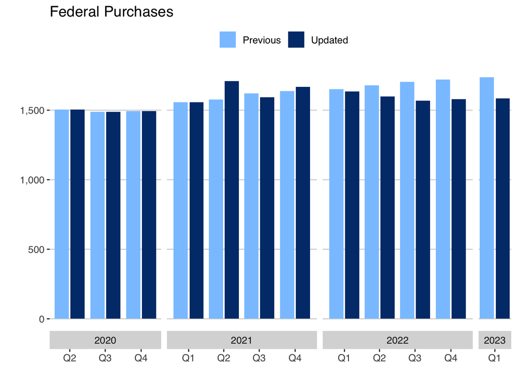

Likewise, consumption grants are higher now given that we reattributed some of the ARP grants away from federal purchases.

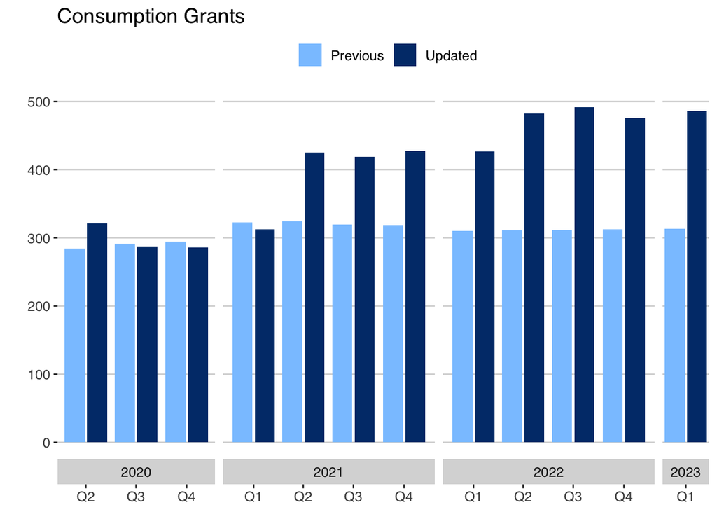

State purchases have been unaffected by any of our changes

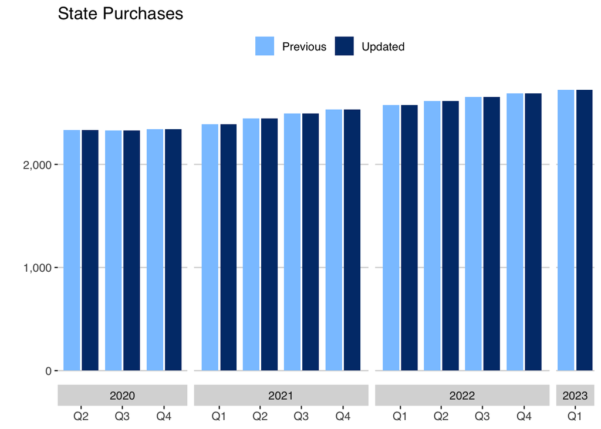

## Transfers

Last time, we forgot to include the rebate checks from ARP that will go out in the next tax year.

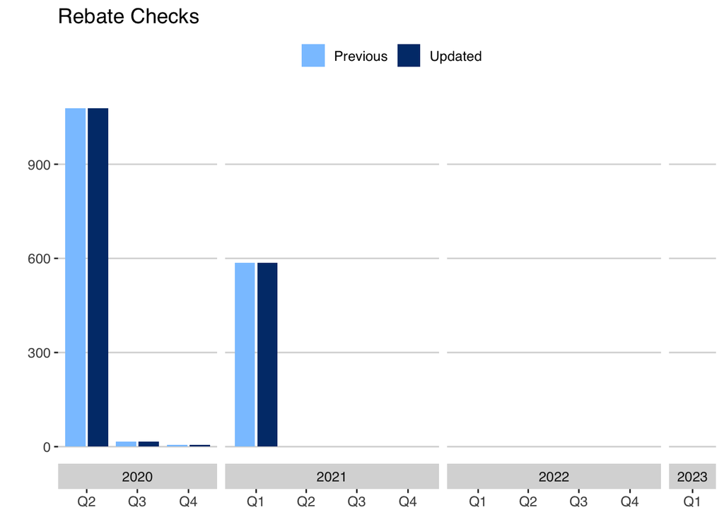

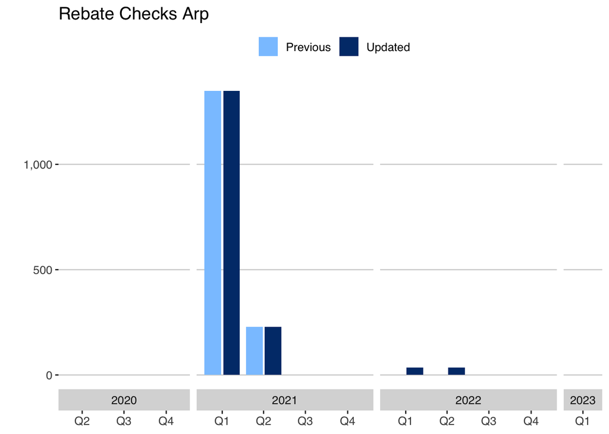

### Health outlays

While our total medicaid forecast is unchanged, we bumped up our forecast for the federal portion of medicaid (Medicaid grants) to reflect the increased FMAP due to the ARP. This increases federal health outlays and decreases state health outlays a litte bit.

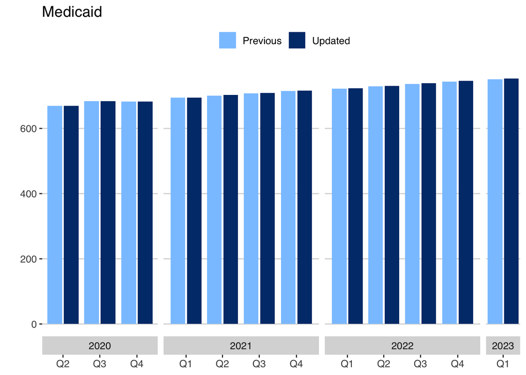

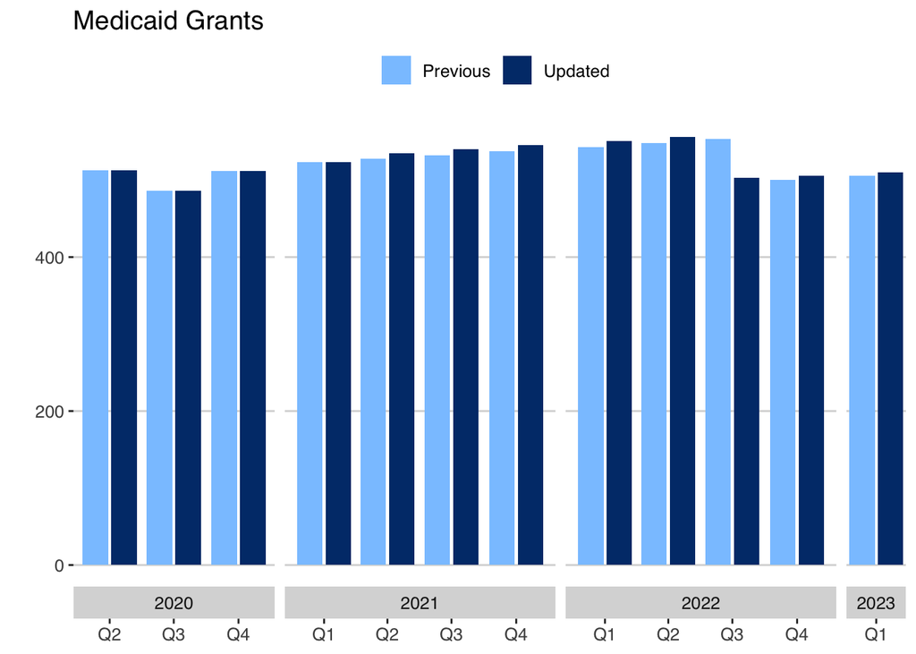

Our medicare forecast is unchanged. The difference of 12 is due to the Medicare sequester which we previously included in our federal health outlays add factor instead of directly into our Medicare forecast.

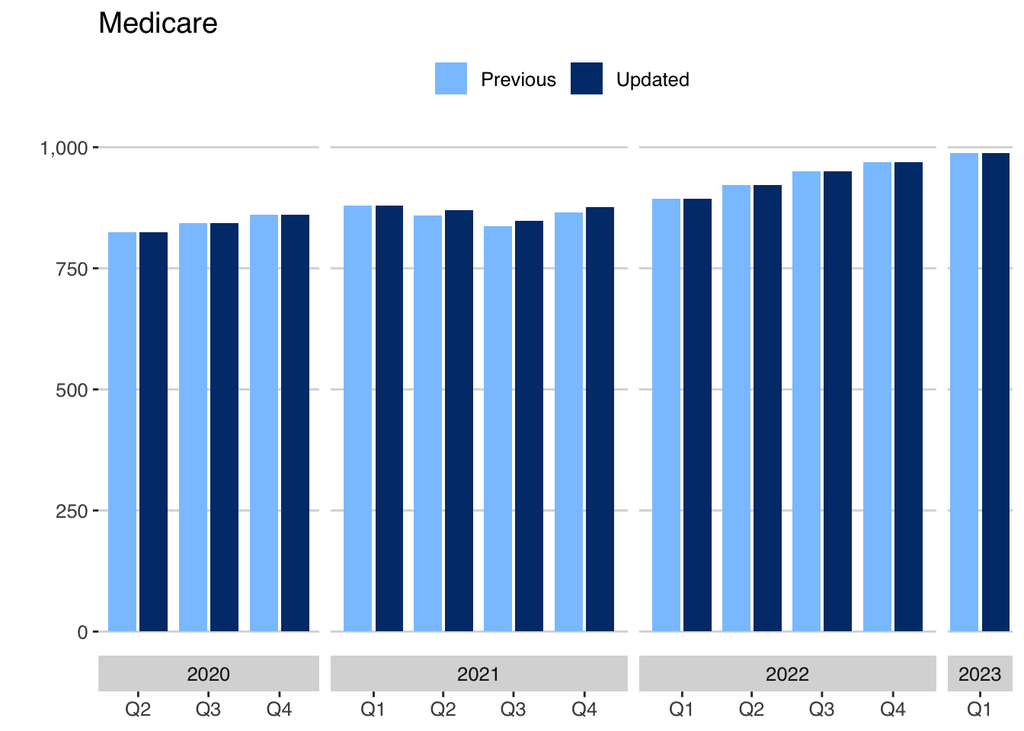

Finally, the bulk of the difference in federal health outlays comes from double counting revenues from Medicaid, Medicare, and CHIP in CBO’s ARP score. We had previously said that health grants from the ARP in Q2 2021 and Q3 2021 were 166.44. Afterwards, we had 60.387 for 4 quarters. Since the MPC for health outlays is high (90% over four quarters), this overestimated the contribution of federal health outlays considerably.

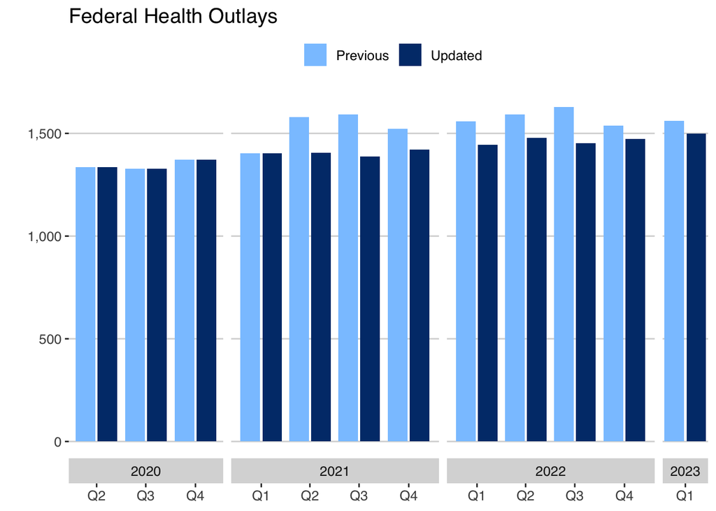

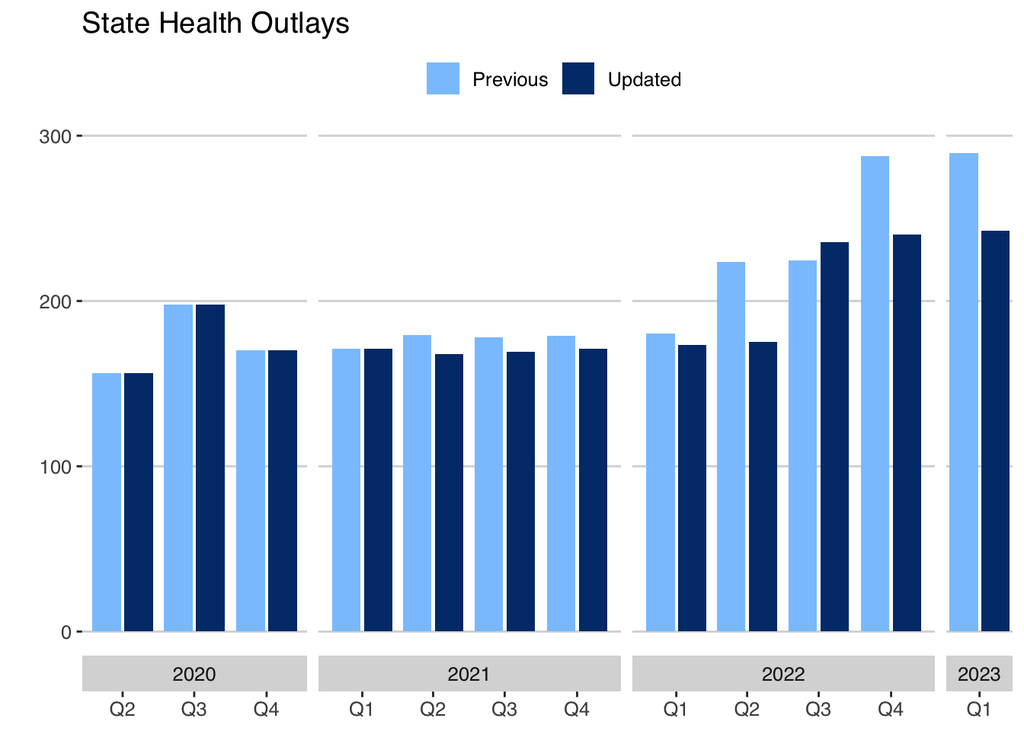

### Unemployment Insurance

Previously, we guessed that regular federal UI would be $20 billion and that the ARP UI was 425.207. Since our ARP score was based on an outdated unemployment rate forecast from CBO, we changed it to reflect higher employment growth due to reopenings.

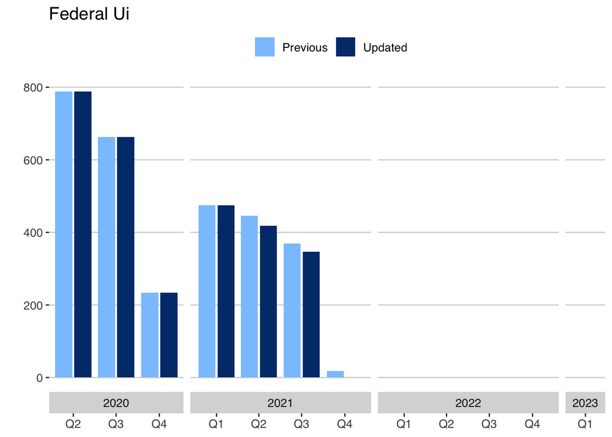

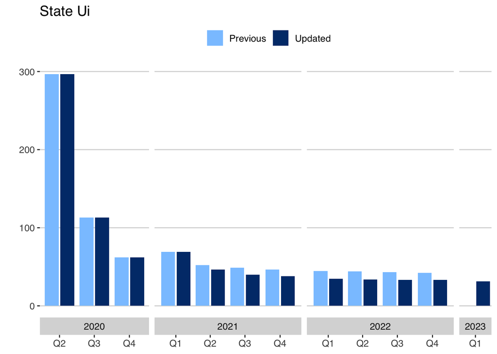

### Subsidies

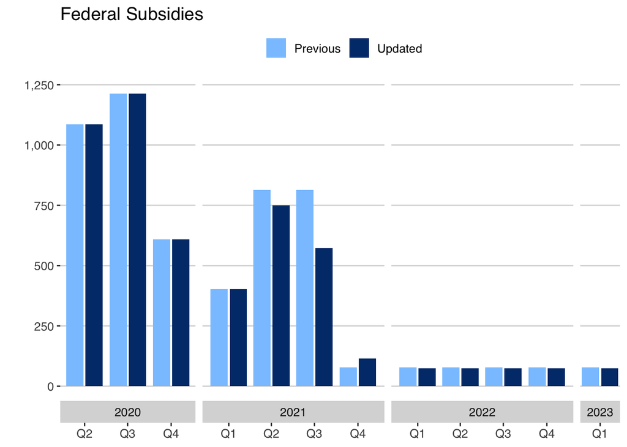

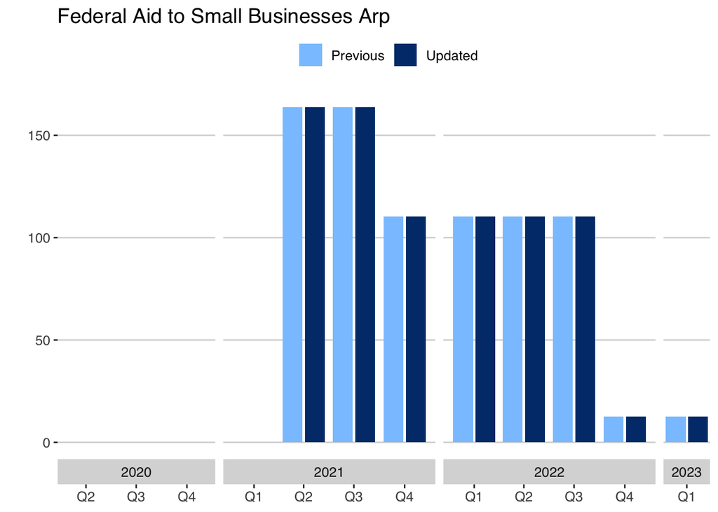

## Other direct aid ARP

Unchanged

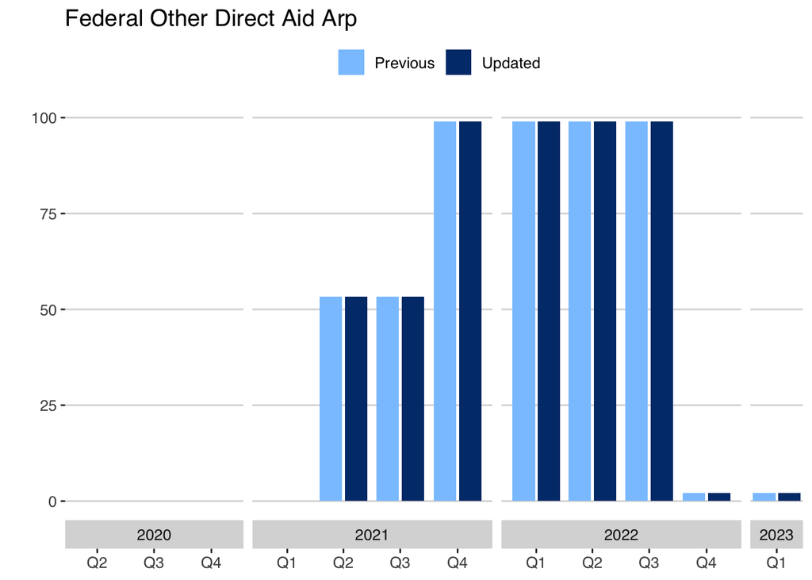

## Other vulnerable ARP

Not sure why this is different. ASK LOUISE

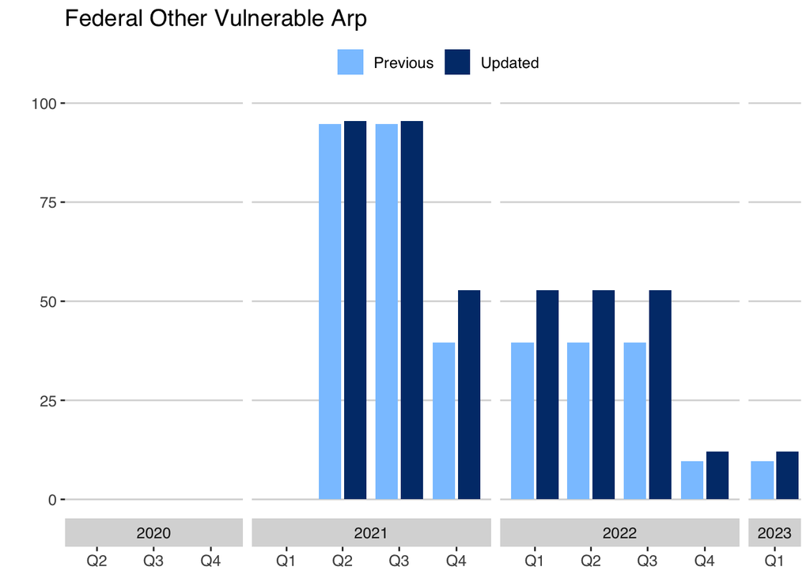

## Social benefits remainder (Net of Medicare, Medicaid, UI, and Rebate checks)

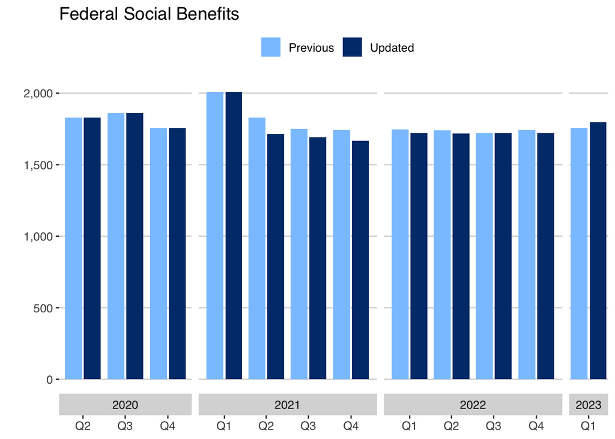